# DEM 7283 - Count Data Models for individual and aggregate data

Corey S. Sparks, Ph.D.

18 May, 2021

This example will cover the use of R functions for fitting count data models to complex survey data and to aggregate data at the county level. Specifically, we focus on the Poisson and Negative Binomial models to individual level survey data as well as for aggregate data.

For this example I am using 2016 CDC Behavioral Risk Factor Surveillance System (BRFSS) SMART data. [Link](https://www.cdc.gov/brfss/smart/smart_2016.html)

We will also use data from the HRSA [Area Resource File](https://data.hrsa.gov/topics/health-workforce/ahrf) on mortality in US counties.

## Poisson distribution for counts or rates

A model that is used commonly for the analysis of count data, meaning integer data, such as the number of deaths, number of crimes or number of cases of a disease, is the *Poisson Distribution*.

For the Poisson model, you observe a count of events in a small area or time period (crimes, deaths, etc). Unlike the Normal distribution, the Poisson is defined strictly for positive integer values.

The Poisson distribution has a single parameter, the mean or $\lambda$. When we construct a model for the mean of the Poisson model, we use a natural logarithm link function. This model is referred to as a type of *log-linear model*.

The mean count of the event, $\lambda$ is linked to the linear mean function through the natural log link:

$$ln(\lambda) = \beta_0 + \beta_1 x_1$$

and using the relationship between exponents and natural logarithms, the mean is:

$$\lambda = \text{exp}( \beta_0 + \beta_1 x_1)$$

which ensures that the linear mean function is always positive, matching the range of the Poisson count data.

## Poisson distribution modeling

The mean of the Poisson distribution, $(\lambda)$, is really the average count for the outcome ($y$). We have several ways of modeling the Poisson count:

- *Pure count model* If each area has the same risk set, or population size, then we can model the mean as-is. This would lead to a model that looks like:

$$log(y)= \beta_0 + \beta_1 x_1$$

When we see the $\beta_1$ parameter in this model in computer output, it is on the log-scale, since that is the scale of the outcome for the Poisson model. In order to interpret the $\beta_1$, we have to *exponentiate* it. When we do this, the parameter is interpreted as the percentage change in the mean of the outcome, for a 1 unit change in $x_1$. For instance if we estimate a model and see in the output that $\beta_1 = \text{.025}$, then $\exp(\beta_1) = \text{exp}(\text{.025}) = \text{1.025}$, or for a 1 unit increase in $x_1$, the mean of $y$ increases by 1.025. So if the mean of $y$ is 10, when $x_1$ = 0, then the mean is $10*(1.025*1)$ or $10.25$ when $x_1$ = 1.

- *Rate model* The second type of modeling strategy is a model for a rate of occurrence. This model includes an *offset term* in the model to incorporate unequal population sizes, this is the most common way the data are analyzed in demographic research. This offset term can be thought of as the denominator for the rate, and we can show how it is put into the model.

If $n$ is the population size for each place, then, we want to do a regression on the rate of occurrence of our outcome. The rate is typically expressed as a proportion, or probability $rate = \frac{y}{n}$:

$$log(y/n)= \beta_0 + \beta_1 x_1$$
$$log(y) - log(n)= \beta_0 + \beta_1 x_1$$

$$log(y)= \beta_0 + \beta_1 x_1 + log(n)$$

Similar to the example from before, when interpreting the effect of $\beta_1$ in this model, we also have to exponentiate it. In this case, the interpretation would not be related to the overall count, but to the rate of occurrence. So, if as before, the $\beta_1 = \text{.025}$, then $\exp(\beta_1) = \text{exp}(\text{.025}) = \text{1.025}$, or for a 1 unit increase in $x_1$, the *rate* of occurrence of $y$ increases by 1.025. If, in this case the average mortality rate was $10/500 = 0.02$ when $x_1$ = 0, then the rate is $0.02*(1.025*1)$ or $0.0205$ when $x_1$ = 1.

## Relative risk analysis

The third type of model for the Poisson distribution focuses on the idea of the relative risk of an event, and uses the *Standardized risk ratio* as its currency.

- The *Standardized risk ratio* incorporates differential exposure due to population size as an *expected count* of the outcome in the offset term, and are typically seen in epidemiological studies. The expected count $E$, incorporates the different population sizes of each area by estimating the number of events that should occur, if the area followed a given rate of occurrence.

The expected count is calculated by multiplying the average rate of occurrence, $r$, by the population size, $n$: $E_i = r * n_i$, where $r = \frac{\sum y_i}{\sum n_i}$, is the overall rate in the population. This method is commonly referred to as *internal standaridization* because we are using the data at hand to estimate the overall rate of occurrence, versus using a rate from some other published source.

The model for the mean of the outcome would look like this:

$$log(y)= \beta_0 + \beta_1 x_1 + log(E)$$
.

## Binomial model for counts

You have probably seen the binomial distribution in either a basic statistics course, remember the coin flips? Or in the context of a logistic regression model.

There are two ways the binomial distribution is typically used, the first is the context of logistic regression, where a special case of the binomial is used, called the *Bernoulli* distribution. This is the case of the binomial when there is basically a single coin flip, and you’re trying to figure out the probability that it is heads (or tails). This is said to be a single *trial*, and the outcome is either 1 or 0 (heads or tails).

The second way the binomial is used is when you have multiple trials, and you’re trying to estimate the probability of the event occurring over multiple trials. In this case, your number of trials, $n$ can be large, and your number of successes, $y$ is the random variable under consideration. This is the basic makeup of a demographic rate, the count-based binomial.

The mean of the binomial distribution is a proportion or a probability, $\pi$, which tells you how likely it is that the event your interested in occurs. Any model using the binomial distributor will be geared towards estimating the probability.

When a variable is coded as binary, meaning either 1 or 0, the Bernoulli distribution is used, as in the logistic regression model. When coded like this, the model tries to use the other measured information to predict the 1 value versus the 0 value. So in the basic sense, we want to construct a model like:

$$Pr(y=1) =\pi = \text{some function of predictors}$$

The good thing is that, when we have count data, not just 1’s and 0’s, the same thing happens. The ratio or successes ($y$) to trials ($n$) is used to estimate $\pi$ and we build a model for that rate:

$$\text{Binomial} \binom{n}{y} = \frac{y}{n} = \pi = \text{some function of predictors}$$

## Binomial regression models

The ratio $\frac{y}{n}$ is a rate or probability, and as such has very strict bounds. Probabilities cannot be less than 0 or greater than 1, so again, we should not use the Normal distribution here, since it is valid for all real numbers. Instead, we are using the binomial, but we still run into the problem of having a strictly bounded value, $\pi$ that we are trying to estimate with a linear function.

Enter the link function again.

The binomial distribution typically uses either a [logit](https://en.wikipedia.org/wiki/Logit) or [probit](https://en.wikipedia.org/wiki/Probit) link function, but others such as the [complementary log-log link function](http://data.princeton.edu/wws509/notes/c3s7.html) are also used in certain circumstances. For now we will use the logit function.

The logit transforms the probability, $\pi$, which is bound on the interval $[0,1]$ into a new limitless interval similar to the normal distribution of $[-\infty, \infty]$. The transformation is knows a the log-odds transformation, or logit for short.

The odds of an event happening are the probability that something happens, divided by the probability it does not happen, in this case:

$$\text{odds }{\pi} = \frac{\pi}{(1-\pi)}$$

Which is bound on the interval $[0, \infty]$, when we take the natural log of the odds, the value is transformed into the linear space, of $[-\infty, \infty]$.

$$\text{log-odds }{\pi} = log \left ( \frac{\pi}{(1-\pi)} \right)$$

This can be modeled using a linear function of covariates now, without worrying about the original boundary problem:

$$log \left ( \frac{\pi}{(1-\pi)} \right) = \beta_0 +\beta_1 x_1$$
or more compactly:

$$log it(\pi) = \beta_0 +\beta_1 x_1$$

```r
#load brfss
library(car)
library(stargazer)
library(survey)
library(sjPlot)
library(ggplot2)
```

## Modeling Overdispersion via a Quasi distribution

For the Poisson , we can fit a “quasi” distribution that adds an extra parameter to allow the mean-variance relationship to not be constant. For Poisson we get:

$$var(Y) = \lambda * \phi$$
, instead of

$$var(Y) = \lambda$$

This allows us to include a rough proxy for a dispersion parameter for the distribution. Naturally this is fixed at 1 for basic models, and estimated in the quasi models, we can look to see if is much bigger than 1. If overdispersion is present and not accounted for you could identify a relationship as being significant when it is not!

## Aggregate data

Data on areal units are very common in demographic research, and prior to the wide scale availability of individual-level microdata from surveys, were the standard data source available for demographic analysis. These are referred to as aggregate data because they represent the total number of events of a given type. For instance, the total number of deaths or total number of births. These are often not measured separately by other demographic characteristics, such as age, race or sex, although certain data sources do provide aggregate measures for specific demographic groups.

- Typically when we get data with a spatial component, they are aggregated to some geography. examples of these are Census tracts
- Census blocks
- Counties
- ZIP codes.

## Calculating Rates

Data measured on these areas are typically raw counts, such as a count of deaths, crimes, births, or people with some characteristic (e.g. people with incomes below the poverty line). These form the numerator for any rate that we might calculate. For the denominator, we hopefully have a population at risk of experiencing the event of interest, such as the total population for a crude death rate, or the number of women between a certain age, for an age specific fertility rate, for instance. Sources of Aggregate Data Examples of places where aggregate data can be obtained are the US Census Bureau’s American Community Survey summary file, which we have been using throughout this course, and the CDC Wonder data portal, which allows for aggregate data on birth and death rates to be extracted.

## Area Resource File

While there are many sources of aggregate data, such as the CDC Wonder site, US Census and a plethora of state agencies, a good national level data resource, which focuses primarily on healthcare access, it the [Health Resource and Service Administration (HRSA)](https://www.hrsa.gov/) [Area Health Resource Files](https://data.hrsa.gov/topics/health-workforce/ahrf).

This data source is published each year, since the mid 1990’s and is publicly available. It uses US Counties as its level of data availability. Google Scholar has more than [3,100 citations](https://scholar.google.com/scholar?q=%22area+resource+file%22&hl=en&as_sdt=0%2C44&as_ylo=2005&as_yhi=) of this data source since 2005, from a variety of disciplines. It has been used for many demographic studies of health and mortality as well.

The data contain a wealth of information on healthcare access and availability, but also large sets of information on basic population counts, Census data and data from the National Center for Health Statistics and the vital registration system.

We will use these data to provide examples of using count data models.

## Applications of count data modeling

Below we will load the 2017-2018 Area Resource File from github and create rename some variables. The data have 7,277 variables for 3,230 county geographies.

```r
arf<-"https://github.com/coreysparks/data/blob/master/arf2018.Rdata?raw=true"
load(url(arf))
```

For this example, we will use the number of low-birth weight births for the three year period, 2014 to 2016. Generally the ARF does not provide annual measures of vital information, instead the provide period measures over 3 or 5 year periods.

For the names of the variables, consult the [data dictionary](https://data.hrsa.gov//DataDownload/AHRF/AHRF_USER_TECH_2017-2018.zip) for the file, which is an Excel spreadsheet with the variable names and descriptions. Descriptions of the original data sources and codes are also available.

For our analysis, we will use the number of low birth weight infants and the total number of births as our numerator and denominator.

```r
library(dplyr)
arf2018<-arf2018%>%
  mutate(cofips=f00004,
         coname=f00010,
         state = f00011,
         births1416=f1254614,
         births0608=f1254608,
         lowbw1416=f1255314,
         lowbw0608=f1255308,
         childpov10= f1332210,
         rucc= as.factor(f0002013),
         hpsa10= as.factor(f0978710),
         obgyn10_pc= 1000*(f1168410/ f0453010) )%>%
  dplyr::select(births1416, lowbw1416,births0608, lowbw0608,state, cofips, coname, childpov10, rucc, hpsa10, obgyn10_pc)%>%
  filter(complete.cases(.))%>%
  as.data.frame()


head(arf2018)
```

|  | births1416 | lowbw1416 | births0608 | lowbw0608 | state | cofips | coname | childpov10 | rucc | hpsa10 | obgyn10_pc |
| --- | --- | --- | --- | --- | --- | --- | --- | --- | --- | --- | --- |
| 1 | 657 | 62 | 701 | 65 | 01 | 01001 | Autauga | 17.5 | 02 | 1 | 0.00000000 |
| 2 | 2278 | 198 | 2194 | 189 | 01 | 01003 | Baldwin | 20.2 | 03 | 1 | 0.11521685 |
| 3 | 276 | 33 | 321 | 41 | 01 | 01005 | Barbour | 36.2 | 06 | 2 | 0.00000000 |
| 4 | 271 | 28 | 247 | 31 | 01 | 01007 | Bibb | 28.6 | 01 | 1 | 0.00000000 |
| 5 | 686 | 55 | 705 | 52 | 01 | 01009 | Blount | 24.1 | 01 | 1 | 0.00000000 |
| 6 | 136 | 22 | 173 | 24 | 01 | 01011 | Bullock | 40.3 | 06 | 1 | 0.09162544 |

```r
summary(arf2018)
```

```
##    births1416       lowbw1416        births0608       lowbw0608
##  Min.   :    67   Min.   :  11.0   Min.   :    84   Min.   :   11.0
##  1st Qu.:   267   1st Qu.:  22.0   1st Qu.:   285   1st Qu.:   23.0
##  Median :   498   Median :  39.0   Median :   520   Median :   43.0
##  Mean   :  1740   Mean   : 140.8   Mean   :  1808   Mean   :  147.7
##  3rd Qu.:  1252   3rd Qu.:  99.0   3rd Qu.:  1299   3rd Qu.:  103.0
##  Max.   :126007   Max.   :8969.0   Max.   :140251   Max.   :10211.0
##
##     state              cofips             coname            childpov10
##  Length:2241        Length:2241        Length:2241        Min.   : 2.70
##  Class :character   Class :character   Class :character   1st Qu.:17.70
##  Mode  :character   Mode  :character   Mode  :character   Median :24.10
##                                                           Mean   :24.43
##                                                           3rd Qu.:30.10
##                                                           Max.   :61.10
##
##       rucc     hpsa10    obgyn10_pc
##  06     :484    :  0   Min.   :0.00000
##  01     :406   0:433   1st Qu.:0.00000
##  02     :355   1:836   Median :0.05730
##  03     :301   2:972   Mean   :0.06921
##  07     :275           3rd Qu.:0.10375
##  04     :214           Max.   :0.82115
##  (Other):206
```

```r
library(tigris)
library(sf)
```

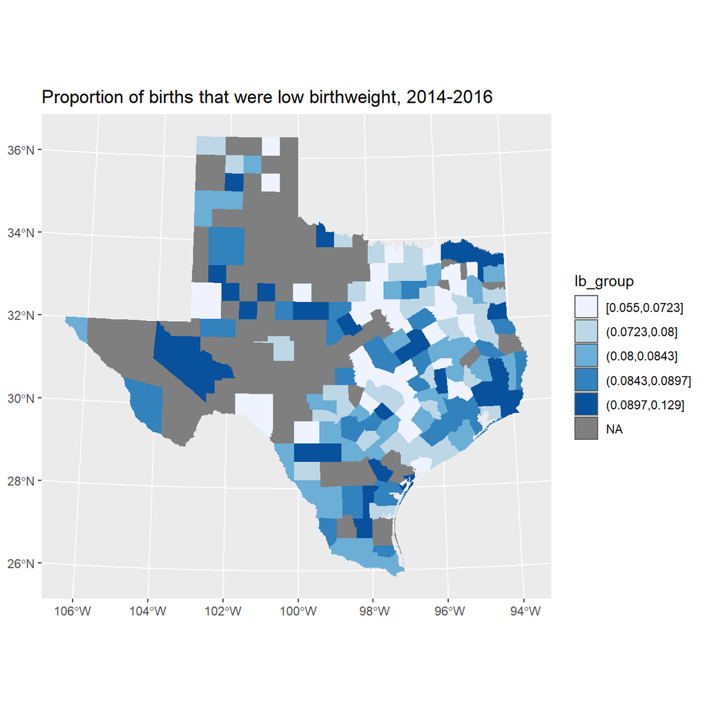

```r
library(ggplot2)

options(tigris_class="sf")
usco<-counties(cb=T, year=2016, state = "TX")
usco$cofips<-usco$GEOID
#sts<-states(cb = T, year=2015)
#sts<-st_boundary(sts)%>%
#  filter(!STATEFP %in% c("02", "15", "60", "66", "69", "72", "78"))

arf2018_m<-geo_join(usco, arf2018, by_sp="cofips", by_df="cofips",how="left" )
arf2018_m%>%
  filter(!STATEFP %in% c("02", "15", "60", "66", "69", "72", "78"))%>%
  mutate(lbrate=lowbw1416/births1416)%>%
  mutate(lb_group = cut(lbrate, breaks=quantile(lbrate, p=seq(0,1,length.out = 6), na.rm=T ), include.lowest=T ))%>%
  ggplot()+
  geom_sf(aes(fill=lb_group, color=NA))+
  scale_color_brewer(palette = "Blues")+
  scale_fill_brewer(palette = "Blues",na.value = "grey50")+
 # geom_sf(data=sts["STATEFP"=="48",], color="black")+
  coord_sf(crs =3083)+
  ggtitle(label = "Proportion of births that were low birthweight, 2014-2016")
```

## Applications of count data models

Now we use the two model, the Poisson and the Binomial to estimate regression models for our low birth weight outcome.

First, we will us the Poisson model. To include the offset term for the number of births in each county, we use the `offset()` function within the model.

In this model, we use the `hpsa10` variable as the independent variable. This variable indicates whether a county has a shortage of primary care doctors, it has three levels, 0 = not a shortage are, 1= the whole county is a shortage are, and 2= part of the county is a shortage area.

The model indicates that counties that are either partial or total shortage areas have higher low birth weight rates.

```r
arf2018sub<-filter(arf2018_m, is.na(lowbw1416)==F)


fit_pois<- glm(lowbw1416 ~ offset(log(births1416)) + hpsa10,
               family=poisson,
               data=arf2018sub)
summary(fit_pois)
```

```
##
## Call:
## glm(formula = lowbw1416 ~ offset(log(births1416)) + hpsa10, family = poisson,
##     data = arf2018sub)
##
## Deviance Residuals:
##     Min       1Q   Median       3Q      Max
## -4.0928  -0.5288  -0.0534   0.5404   4.0552
##
## Coefficients:
##              Estimate Std. Error  z value Pr(>|z|)
## (Intercept) -2.528330   0.018273 -138.367  < 2e-16 ***
## hpsa101      0.056675   0.019503    2.906  0.00366 **
## hpsa102      0.007692   0.021337    0.360  0.71848
## ---
## Signif. codes:  0 '***' 0.001 '**' 0.01 '*' 0.05 '.' 0.1 ' ' 1
##
## (Dispersion parameter for poisson family taken to be 1)
##
##     Null deviance: 200.20  on 160  degrees of freedom
## Residual deviance: 180.74  on 158  degrees of freedom
## AIC: 1128.7
##
## Number of Fisher Scoring iterations: 4
```

If we exponentiate the coefficients from the model, we can get the risk ratios:

```r
exp(coef(fit_pois))
```

```
## (Intercept)     hpsa101     hpsa102
##  0.07979219  1.05831180  1.00772122
```

In this case, the `hpsa10, 1`, or whole shortage area counties, have a mean low birth-weight rate that is 5.8% higher than counties that are not shortage areas, and counties that are partial shortage areas, `hpsa10, 2` have a mean low birth weight rate that is .7% higher.

In practical terms, we can calculate these rates ourselves, after extracting the estimated counts of low birth weight births:

```r
arf2018sub$est_pois<- fitted(fit_pois)

arf2018sub$est_rate<- arf2018sub$est_pois/ arf2018sub$births1416

aggregate(est_rate ~ hpsa10, data=arf2018sub, FUN = mean)
```

| hpsa10 | est_rate |
| --- | --- |
| 0 | 0.07979219 |
| 1 | 0.08444502 |
| 2 | 0.08040829 |

We can show through arithmetic that the difference between `hpsa10` level 0 and `hpsa10` level 1 is 5.8% and the difference between the `hpsa10` level 0 and `hpsa10` level 2 is 0.7%

```r
(0.08444 - 0.07979)/0.07979
```

```
## [1] 0.05827798
```

```r
(0.0804 - 0.07979)/0.07979
```

```
## [1] 0.007645068
```

## Issues with the Poisson model

The Poisson distribution model has a strong assumption to it, the assumption is that the mean and variance of the Poisson model are the same. If the variance is greater than the mean, then the model has an *overdispersion* problem, meaning the variance is greater than the mean.

There is a general test to examine this in a Poisson model, and it relies on the model fit statistics generated by the`summary()` function.

Two numbers in the model summary, the residual deviance and the residual degrees of freedom. If the Poisson model is fitting the data appropriately, then these two values will be the same, or very similar. As the residual deviance becomes larger than the residual degrees of freedom, the model becomes more over dispersed.

A check of this is to examine the ratio of these to values:

```r
scale<-sqrt(fit_pois$deviance/fit_pois$df.residual)
scale
```

```
## [1] 1.069537
```

There is also a test statistic that can be used, referred to as a *goodness of fit statistic*. This compares the model deviance to a $\chi^2$ distribution with degrees of freedom equal to the residual degrees of freedom. Small p-values for this test, suggest the model does not fit the data.

```r
1-pchisq(fit_pois$deviance, df = fit_pois$df.residual)
```

```
## [1] 0.1039231
```

In this case, the statistic has a p-value of .10, indicating the model fits the data ok.

If this statistical test was significant, then we would have evidence of overdispersion in the data. When overdispersion is present in a model, the model results cannot be trusted, because the test statistics of the model rely on the assumptions to be correct.